# PISA Dataset Analysis

## Preliminary Wrangling

According to [Wikipedia](https://en.wikipedia.org/wiki/Programme_for_International_Student_Assessment), the Programme for International Student Assessment (PISA) is a worldwide study by the Organisation for Economic Co-operation and Development (OECD) in member and non-member nations intended to evaluate educational systems by measuring 15-year-old school pupils' scholastic performance on mathematics, science, and reading.

Around 510,000 students in 65 economies took part in the PISA 2012 assessment of reading, mathematics and science representing about 28 million 15-year-olds globally. Of those economies, 44 took part in an assessment of creative problem solving and 18 in an assessment of financial literacy.

In this notebook, we´re going to process the PISA dataset from 2012, which we downloaded from [Udacity servers](https://www.google.com/url?q=https://s3.amazonaws.com/udacity-hosted-downloads/ud507/pisa2012.csv.zip&sa=D&ust=1566844420961000).

```python
# Import all packages and set plots to be embedded inline
import numpy as np
import pandas as pd
import matplotlib.pyplot as plt
import seaborn as sb

%matplotlib inline
```

```python
# Create a dataframe from the pisa2012.csv file
df_pisa = pd.read_csv('pisa2012.csv', encoding='ISO-8859-1')
df_pisa.head(1)
```

|  | Unnamed: 0 | CNT | SUBNATIO | STRATUM | OECD | NC | SCHOOLID | STIDSTD | ST01Q01 | ST02Q01 | ST03Q01 | ST03Q02 | ST04Q01 | ST05Q01 | ST06Q01 | ST07Q01 | ST07Q02 | ST07Q03 | ST08Q01 | ST09Q01 | ST115Q01 | ST11Q01 | ST11Q02 | ST11Q03 | ST11Q04 | ST11Q05 | ST11Q06 | ST13Q01 | ST14Q01 | … |
| --- | --- | --- | --- | --- | --- | --- | --- | --- | --- | --- | --- | --- | --- | --- | --- | --- | --- | --- | --- | --- | --- | --- | --- | --- | --- | --- | --- | --- | --- | --- |
| 0 | 1 | Albania | 80000 | ALB0006 | Non-OECD | Albania | 1 | 1 | 10 | 1.0 | 2 | 1996 | Female | No | 6.0 | No, never | No, never | No, never | None | None | 1.0 | Yes | Yes | Yes | Yes | NaN | NaN | <ISCED level 3A> | No | … |

1 rows × 636 columns

```python
df_pisa.shape
```

```
(485490, 636)
```

```python
# Create a dataframe from the pisa dictionary csv file
df_pisa_dict = pd.read_csv('pisadict2012.csv', encoding='ISO-8859-1')
df_pisa_dict.head(5)
```

|  | Unnamed: 0 | x |
| --- | --- | --- |
| 0 | CNT | Country code 3-character |
| 1 | SUBNATIO | Adjudicated sub-region code 7-digit code (3-di... |
| 2 | STRATUM | Stratum ID 7-character (cnt + region ID + orig... |
| 3 | OECD | OECD country |
| 4 | NC | National Centre 6-digit Code |

```python
# List the column names
list(df_pisa_dict.x)
```

```
['Country code 3-character',
 'Adjudicated sub-region code 7-digit code (3-digit country code + region ID + stratum ID)',
 'Stratum ID 7-character (cnt + region ID + original stratum ID)',
 'OECD country',
 'National Centre 6-digit Code',
 'School ID 7-digit (region ID + stratum ID + 3-digit school ID)',
 'Student ID',
 'International Grade',
 'National Study Programme',
 'Birth - Month',
 'Birth -Year',
 'Gender',
 'Attend <ISCED 0>',
 'Age at <ISCED 1>',
 'Repeat - <ISCED 1>',
 'Repeat - <ISCED 2>',
 'Repeat - <ISCED 3>',
 'Truancy - Late for School',
 'Truancy - Skip whole school day',
 'Truancy - Skip classes within school day',
 'At Home - Mother',
 'At Home - Father',
 'At Home - Brothers',
 'At Home - Sisters',
 'At Home - Grandparents',
 'At Home - Others',
 'Mother<Highest Schooling>',
 'Mother Qualifications - <ISCED level 6>',
 'Mother Qualifications - <ISCED level 5A>',
 'Mother Qualifications - <ISCED level 5B>',
 'Mother Qualifications - <ISCED level 4>',
 'Mother Current Job Status',
 'Father<Highest Schooling>',
 'Father Qualifications - <ISCED level 6>',
 'Father Qualifications - <ISCED level 5A>',
 'Father Qualifications - <ISCED level 5B>',
 'Father Qualifications - <ISCED level 4>',
 'Father Current Job Status',
 'Country of Birth International - Self',
 'Country of Birth International - Mother',
```

[output cut: 580 more lines]

```
 'FINAL STUDENT REPLICATE BRR-FAY WEIGHT70',
 'FINAL STUDENT REPLICATE BRR-FAY WEIGHT71',
 'FINAL STUDENT REPLICATE BRR-FAY WEIGHT72',
 'FINAL STUDENT REPLICATE BRR-FAY WEIGHT73',
 'FINAL STUDENT REPLICATE BRR-FAY WEIGHT74',
 'FINAL STUDENT REPLICATE BRR-FAY WEIGHT75',
 'FINAL STUDENT REPLICATE BRR-FAY WEIGHT76',
 'FINAL STUDENT REPLICATE BRR-FAY WEIGHT77',
 'FINAL STUDENT REPLICATE BRR-FAY WEIGHT78',
 'FINAL STUDENT REPLICATE BRR-FAY WEIGHT79',
 'FINAL STUDENT REPLICATE BRR-FAY WEIGHT80',
 'RANDOMIZED FINAL VARIANCE STRATUM (1-80)',
 'RANDOMLY ASSIGNED VARIANCE UNIT',
 'Senate weight - sum of weight within the country is 1000',
 'Date of the database creation']
```

As the original pisa file is huge in size, we will create another smaller one to ease our work dealing with it.

To create it we have copied explored visually the csv file on a Google Sheet. Then, we have selected one subset of columns we are going to base our analysis on.

Now, we are going to create a dataframe with that subset.

```python
# Update the column names of the pisa csv file with the column names from the dictionary

# Create a list of column names from the dictionary
dict_column_names = ['']
for _ in df_pisa_dict['x']:
    dict_column_names.append(_)

# Assign the list of column names to the pisa dataframe
df_pisa.columns = dict_column_names

df_pisa.head(1)
```

|  |  | Country code 3-character | Adjudicated sub-region code 7-digit code (3-digit country code + region ID + stratum ID) | Stratum ID 7-character (cnt + region ID + original stratum ID) | OECD country | National Centre 6-digit Code | School ID 7-digit (region ID + stratum ID + 3-digit school ID) | Student ID | International Grade | National Study Programme | Birth - Month | Birth -Year | Gender | Attend <ISCED 0> | Age at <ISCED 1> | Repeat - <ISCED 1> | Repeat - <ISCED 2> | Repeat - <ISCED 3> | Truancy - Late for School | Truancy - Skip whole school day | Truancy - Skip classes within school day | At Home - Mother | At Home - Father | At Home - Brothers | At Home - Sisters | At Home - Grandparents | At Home - Others | Mother<Highest Schooling> | Mother Qualifications - <ISCED level 6> | … |
| --- | --- | --- | --- | --- | --- | --- | --- | --- | --- | --- | --- | --- | --- | --- | --- | --- | --- | --- | --- | --- | --- | --- | --- | --- | --- | --- | --- | --- | --- | --- |
| 0 | 1 | Albania | 80000 | ALB0006 | Non-OECD | Albania | 1 | 1 | 10 | 1.0 | 2 | 1996 | Female | No | 6.0 | No, never | No, never | No, never | None | None | 1.0 | Yes | Yes | Yes | Yes | NaN | NaN | <ISCED level 3A> | No | … |

1 rows × 636 columns

```python
# Create a new dataframe with the columns we want to keep
# To get to this group, we´ve iterated several times during the creation of this notebook
df_pisa_small = df_pisa[[
    'Birth - Month',
    'Gender',
    'How many books at home',
    'At school - Desktop Computer',
    'At school - Portable laptop',
    'Age of student',
    'Out-of-School Study Time - Homework',
    'Home Possessions',
    'Possessions - computer',
    'Plausible value 1 in mathematics',
    'Plausible value 2 in mathematics',
    'Plausible value 3 in mathematics',
    'Plausible value 4 in mathematics',
    'Plausible value 5 in mathematics',
    'Plausible value 1 in reading',
    'Plausible value 2 in reading',
    'Plausible value 3 in reading',
    'Plausible value 4 in reading',
    'Plausible value 5 in reading',
    'Plausible value 1 in science',
    'Plausible value 2 in science',
    'Plausible value 3 in science',
    'Plausible value 4 in science',
    'Plausible value 5 in science',
    'Wealth',
]]

df_pisa_small.head(1)
```

|  | Birth - Month | Gender | How many books at home | At school - Desktop Computer | At school - Portable laptop | Age of student | Out-of-School Study Time - Homework | Home Possessions | Possessions - computer | Plausible value 1 in mathematics | Plausible value 2 in mathematics | Plausible value 3 in mathematics | Plausible value 4 in mathematics | Plausible value 5 in mathematics | Plausible value 1 in reading | Plausible value 2 in reading | Plausible value 3 in reading | Plausible value 4 in reading | Plausible value 5 in reading | Plausible value 1 in science | Plausible value 2 in science | Plausible value 3 in science | Plausible value 4 in science | Plausible value 5 in science | Wealth |
| --- | --- | --- | --- | --- | --- | --- | --- | --- | --- | --- | --- | --- | --- | --- | --- | --- | --- | --- | --- | --- | --- | --- | --- | --- | --- |
| 0 | 2 | Female | 0-10 books | NaN | NaN | 16.17 | NaN | -2.61 | No | 406.8469 | 376.4683 | 344.5319 | 321.1637 | 381.9209 | 249.5762 | 254.342 | 406.8496 | 175.7053 | 218.5981 | 341.7009 | 408.84 | 348.2283 | 367.8105 | 392.9877 | -2.92 |

```python
# Lowercase and add _ to each column name
df_pisa_small.columns = map(str.lower, df_pisa_small.columns)
df_pisa_small.columns = df_pisa_small.columns.str.replace(' ', '_')
df_pisa_small.head(1)
```

|  | birth_-_month | gender | how_many_books_at_home | at_school_-_desktop_computer | at_school_-_portable_laptop | age_of_student | out-of-school_study_time_-_homework | home_possessions | possessions_-_computer | plausible_value_1_in_mathematics | plausible_value_2_in_mathematics | plausible_value_3_in_mathematics | plausible_value_4_in_mathematics | plausible_value_5_in_mathematics | plausible_value_1_in_reading | plausible_value_2_in_reading | plausible_value_3_in_reading | plausible_value_4_in_reading | plausible_value_5_in_reading | plausible_value_1_in_science | plausible_value_2_in_science | plausible_value_3_in_science | plausible_value_4_in_science | plausible_value_5_in_science | wealth |
| --- | --- | --- | --- | --- | --- | --- | --- | --- | --- | --- | --- | --- | --- | --- | --- | --- | --- | --- | --- | --- | --- | --- | --- | --- | --- |
| 0 | 2 | Female | 0-10 books | NaN | NaN | 16.17 | NaN | -2.61 | No | 406.8469 | 376.4683 | 344.5319 | 321.1637 | 381.9209 | 249.5762 | 254.342 | 406.8496 | 175.7053 | 218.5981 | 341.7009 | 408.84 | 348.2283 | 367.8105 | 392.9877 | -2.92 |

```python
# Create score columns from the plausible values ones

df_pisa_small['math_score'] = (df_pisa_small['plausible_value_1_in_mathematics'] +\
                               df_pisa_small['plausible_value_2_in_mathematics'] +\
                               df_pisa_small['plausible_value_3_in_mathematics'] +\
                               df_pisa_small['plausible_value_4_in_mathematics'] +\
                               df_pisa_small['plausible_value_5_in_mathematics']) / 5

df_pisa_small['reading_score'] = (df_pisa_small['plausible_value_1_in_reading'] +\
                               df_pisa_small['plausible_value_2_in_reading'] +\
                               df_pisa_small['plausible_value_3_in_reading'] +\
                               df_pisa_small['plausible_value_4_in_reading'] +\
                               df_pisa_small['plausible_value_5_in_reading']) / 5

df_pisa_small['science_score'] = (df_pisa_small['plausible_value_1_in_science'] +\
                                  df_pisa_small['plausible_value_2_in_science'] +\
                                  df_pisa_small['plausible_value_3_in_science'] +\
                                  df_pisa_small['plausible_value_4_in_science'] +\
                                  df_pisa_small['plausible_value_5_in_science']) / 5

# Drop plausible values colums
df_pisa_small.drop(columns=['plausible_value_1_in_mathematics',
                            'plausible_value_2_in_mathematics',
                            'plausible_value_3_in_mathematics',
                            'plausible_value_4_in_mathematics',
                            'plausible_value_5_in_mathematics',
                            'plausible_value_1_in_reading',
                            'plausible_value_2_in_reading',
                            'plausible_value_3_in_reading',
                            'plausible_value_4_in_reading',
                            'plausible_value_5_in_reading',
                            'plausible_value_1_in_science',
                            'plausible_value_2_in_science',
                            'plausible_value_3_in_science',
                            'plausible_value_4_in_science',
                            'plausible_value_5_in_science'
                            ], inplace=True)

df_pisa_small.head(1)
```

|  | birth_-_month | gender | how_many_books_at_home | at_school_-_desktop_computer | at_school_-_portable_laptop | age_of_student | out-of-school_study_time_-_homework | home_possessions | possessions_-_computer | wealth | math_score | reading_score | science_score |
| --- | --- | --- | --- | --- | --- | --- | --- | --- | --- | --- | --- | --- | --- |
| 0 | 2 | Female | 0-10 books | NaN | NaN | 16.17 | NaN | -2.61 | No | -2.92 | 366.18634 | 261.01424 | 371.91348 |

```python
# Let´s visually inspect our dataframe
df_pisa_small.sample(500)
```

[output not shown]

[output cut: 470 more lines]

```python
df_pisa_small.describe()
```

|  | birth_-_month | age_of_student | out-of-school_study_time_-_homework | home_possessions | wealth | math_score | reading_score | science_score |
| --- | --- | --- | --- | --- | --- | --- | --- | --- |
| count | 485490.000000 | 485374.000000 | 301367.000000 | 479807.000000 | 479597.00000 | 485490.000000 | 485490.000000 | 485490.000000 |
| mean | 6.558512 | 15.784283 | 5.493770 | -0.324815 | -0.33701 | 469.651234 | 472.006964 | 475.808094 |
| std | 3.705244 | 0.290221 | 5.383815 | 1.163213 | 1.21530 | 100.786610 | 98.863310 | 97.998470 |
| min | 1.000000 | 15.170000 | 0.000000 | -6.880000 | -6.65000 | 54.767080 | 6.445400 | 25.158540 |
| 25% | 4.000000 | 15.580000 | 2.000000 | -0.980000 | -1.04000 | 396.019620 | 405.044200 | 405.762800 |
| 50% | 7.000000 | 15.750000 | 4.000000 | -0.260000 | -0.30000 | 465.734520 | 475.477980 | 475.512860 |
| 75% | 9.000000 | 16.000000 | 7.000000 | 0.390000 | 0.43000 | 540.123060 | 542.831195 | 546.381920 |
| max | 99.000000 | 16.330000 | 30.000000 | 4.150000 | 3.25000 | 903.107960 | 849.359740 | 857.832900 |

```python
df_pisa_small.info()
```

[output not shown]

```python
# Let´s prepare to do some cleaning
df_clean = df_pisa_small.copy()
```

```python
# Let´s get rid of rows with null values
df_clean = df_clean.dropna()
df_clean.info()
```

```
<class 'pandas.core.frame.DataFrame'>
Int64Index: 185626 entries, 22151 to 475552
Data columns (total 13 columns):
birth_-_month                          185626 non-null int64
gender                                 185626 non-null object
how_many_books_at_home                 185626 non-null object
at_school_-_desktop_computer           185626 non-null object
at_school_-_portable_laptop            185626 non-null object
age_of_student                         185626 non-null float64
out-of-school_study_time_-_homework    185626 non-null float64
home_possessions                       185626 non-null float64
possessions_-_computer                 185626 non-null object
wealth                                 185626 non-null float64
math_score                             185626 non-null float64
reading_score                          185626 non-null float64
science_score                          185626 non-null float64
dtypes: float64(7), int64(1), object(5)
memory usage: 19.8+ MB
```

```python
# Let´s change the type to the columns that hold categorical data
categorical_data = ['gender',
                    'how_many_books_at_home',
                    'at_school_-_desktop_computer',
                    'at_school_-_portable_laptop',
                    'possessions_-_computer']

for cat in categorical_data:
    df_clean[cat] = df_clean[cat].astype('category')

df_clean.info()
```

```
<class 'pandas.core.frame.DataFrame'>
Int64Index: 185626 entries, 22151 to 475552
Data columns (total 13 columns):
birth_-_month                          185626 non-null int64
gender                                 185626 non-null category
how_many_books_at_home                 185626 non-null category
at_school_-_desktop_computer           185626 non-null category
at_school_-_portable_laptop            185626 non-null category
age_of_student                         185626 non-null float64
out-of-school_study_time_-_homework    185626 non-null float64
home_possessions                       185626 non-null float64
possessions_-_computer                 185626 non-null category
wealth                                 185626 non-null float64
math_score                             185626 non-null float64
reading_score                          185626 non-null float64
science_score                          185626 non-null float64
dtypes: category(5), float64(7), int64(1)
memory usage: 13.6 MB
```

```python
df_clean.shape
```

```
(185626, 13)
```

```python
# Let´s create a sample of our data to ease the calculation time for our charts and reduce the number of datapoints
df_sample = df_clean.sample(1000)

# Let´s create an average of the pisa scores
df_sample['pisa_score_average'] = (df_sample['reading_score'] + df_sample['math_score'] + df_sample['science_score'])/3
df_sample.head(1)
```

|  | birth_-_month | gender | how_many_books_at_home | at_school_-_desktop_computer | at_school_-_portable_laptop | age_of_student | out-of-school_study_time_-_homework | home_possessions | possessions_-_computer | wealth | math_score | reading_score | science_score | pisa_score_average |
| --- | --- | --- | --- | --- | --- | --- | --- | --- | --- | --- | --- | --- | --- | --- |
| 109140 | 12 | Male | 11-25 books | Yes, and I use it | Yes, but I dont use it | 15.67 | 3.0 | 0.11 | Yes | 0.68 | 417.98568 | 482.27152 | 468.61244 | 456.28988 |

```python
# Save the new dataframe to a new csv file to ease work with
df_pisa_small.to_csv('pisa2012_small.csv', encoding='utf-8', index=False)
```

The new csv file size is 51MB vs 2.75GB from the original pisa2012.csv file. This will make us easier to work with the data loading only this file instead of the full archive.

### What is the structure of your dataset?

After some rounds of data wrangling with the original pisa2012 dataset containing close to 500k rows and more than 600 columns, we have ended up with a dataset of 186k rows and 13 colunns.

### What is/are the main feature(s) of interest in your dataset?

The main features of interest we want to study in this dataset are the different PISA scores and particularly their relations with wealth.

These are some of the questions we plan to answer:

- Are PISA scores correlated betweeen them?
- What´s the influence of wealth in the scores?
- Doing homework out of class improve your scores?
- Do wealthy students do more homework than non-wealthy ones?
- Do students with more books at home obtain better scores?
- Owning a computer improves your scores?

### What features in the dataset do you think will help support your investigation into your feature(s) of interest?

Data about wealth, possesions and number of books at home are some of the features I want to rely on to do my analysis.

## Univariate Exploration

Our main variables of interest are those related with the Pisa Scores. Let´s look what distribution do they have.

```python
import seaborn as sns
sns.set_style("white")
sns.despine()

# Function that we will use during the exercise to decorate our charts",
def decorate(title, xlabel, ylabel, xticks=None, xticklabels=None, yticks=None, yticklabels=None):
    ax.set_title(title, fontsize=22)
    ax.set_xlabel(xlabel)
    ax.set_ylabel(ylabel)
    if xticks is not None:
        ax.set_xticks(xticks)
    if xticklabels is not None:
        ax.set_xticklabels(xticklabels, rotation=70)
    if yticks is not None:
            ax.set_xticks(yticks)
    if yticklabels is not None:
        ax.set_xticklabels(yticklabels, rotation=70)
#    fig.tight_layout()

# Function that we will use during the exercise to decorate our charts",
def decorate_subplot(subplot, title, xlabel, ylabel, xticks=None, xticklabels=None, yticks=None, yticklabels=None):
    subplot.set_title(title, fontsize=14)
    subplot.set_xlabel(xlabel)
    subplot.set_ylabel(ylabel)
    if xticks is not None:
        subplot.set_xticks(xticks)
    if xticklabels is not None:
        subplot.set_xticklabels(xticklabels, rotation=70)
    if yticks is not None:
            subplot.set_xticks(yticks)
    if yticklabels is not None:
        subplot.set_xticklabels(yticklabels, rotation=70)
    subplot.grid(alpha=1)
#    fig.tight_layout()
```

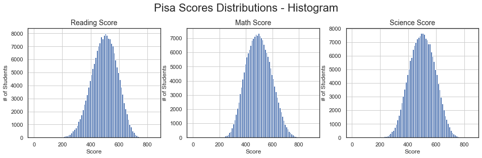

```python
# Histograms for pisa scores

plt.figure(figsize=(16,4))
plt.suptitle('Pisa Scores Distributions - Histogram', fontsize=22, y='1.05')

# First subplot
ax1 = plt.subplot(1, 3, 1) # 1 row, 3 cols, subplot 1
bin_edges = np.arange(0, df_clean['reading_score'].max()+10, 10)
plt.hist(data = df_clean, x = 'reading_score', bins = bin_edges);
decorate_subplot(ax1, "Reading Score", "Score", "# of Students")

# Second subplot
ax2 = plt.subplot(1, 3, 2)
bin_edges = np.arange(0, df_clean['math_score'].max()+10, 10)
plt.hist(data = df_clean, x = 'math_score', bins = bin_edges);
decorate_subplot(ax2, "Math Score", "Score", "# of Students")

# Third subplot
ax3 = plt.subplot(1, 3, 3)
bin_edges = np.arange(0, df_clean['science_score'].max()+10, 10)
plt.hist(data = df_clean, x = 'science_score', bins = bin_edges);
decorate_subplot(ax3, "Science Score", "Score", "# of Students")

plt.show()
```

The different Pisa scores for reading, math and science follow a normal distribution.

Let´s plot next some of our other variables of interest.

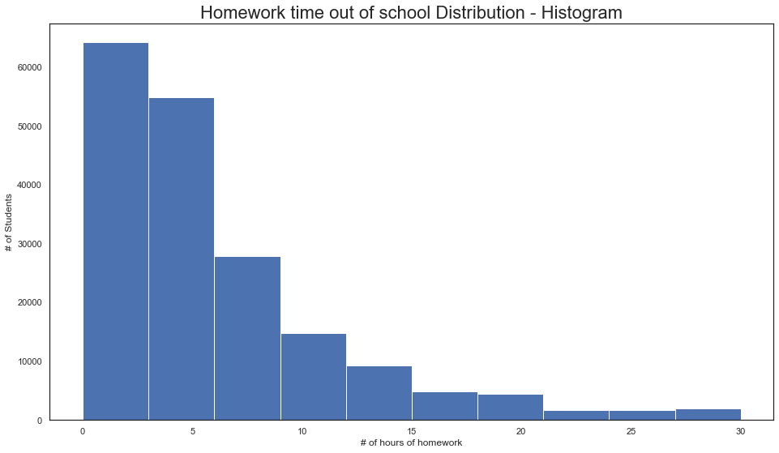

```python
# Histogram for time of homework
fig, ax = plt.subplots(figsize=(16,9))
ax.hist(data = df_clean, x = 'out-of-school_study_time_-_homework')
decorate("Homework time out of school Distribution - Histogram", "# of hours of homework", "# of Students")
plt.show();
```

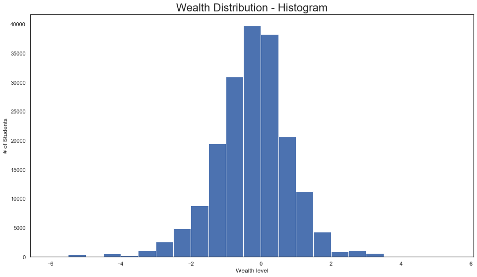

```python
# Histogram for wealth
bin_edges = np.arange(-6, 6, 0.5)
fig, ax = plt.subplots(figsize=(16,9))
ax.hist(data = df_clean, x = 'wealth', bins=bin_edges)
decorate("Wealth Distribution - Histogram", "Wealth level", "# of Students")
plt.show();
```

The distribution also seems normal, slightly skewed to the left.

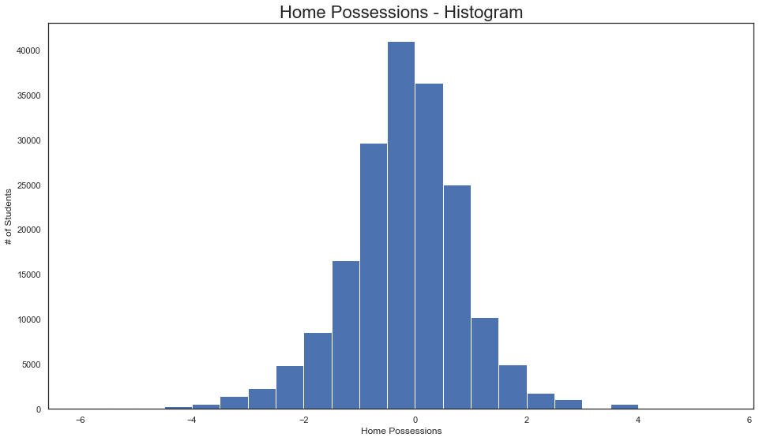

```python
# Histogram for wealth
bin_edges = np.arange(-6, 6, 0.5)
fig, ax = plt.subplots(figsize=(16,9))
ax.hist(data = df_clean, x = 'home_possessions', bins=bin_edges)
decorate("Home Possessions - Histogram", "Home Possessions", "# of Students")
plt.show();
```

Also, the distribution of home possessions follow a normal distribution.

Let´s continue now with other of our variables of Interest, the number of books in each household.

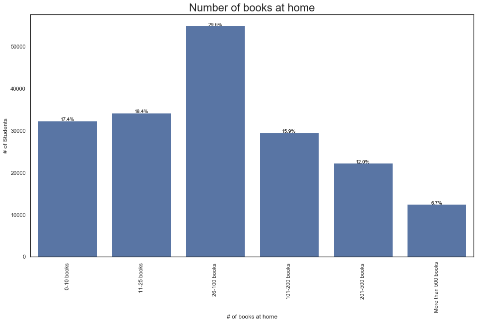

```python
base_color = sb.color_palette()[0]
books_order = ["0-10 books ", "11-25 books ", "26-100 books ", "101-200 books ", "201-500 books ", "More than 500 books"]

# Plot
fig = plt.subplots(figsize=(16,9))
ax = sb.countplot(data=df_clean,
             x='how_many_books_at_home',
             color=base_color,
             order=books_order);
decorate("Number of books at home", "# of books at home", "# of Students")
plt.xticks(rotation=90)

# Add function to add annotations
def add_percentage_annotations(df, column):
    n_points = df.shape[0]
    cat_counts = df[column].value_counts()
    locs, labels = plt.xticks() # get the current tick locations and labels

    # loop through each pair of locations and labels
    for loc, label in zip(locs, labels):

        # get the text property for the label to get the correct count
        count = cat_counts[label.get_text()]
        pct_string = '{:0.1f}%'.format(100*count/n_points)

        # print the annotation just below the top of the bar
        plt.text(loc, count-8, pct_string, ha = 'center', color = '0')

add_percentage_annotations(df_clean, 'how_many_books_at_home')
```

Let´s see how many students have computers in their own.

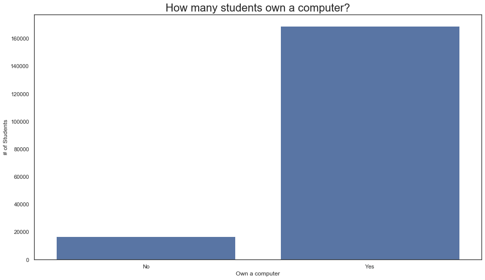

```python
# Plot the birth month variable
fig = plt.subplots(figsize=(16,9))
ax = sb.countplot(data=df_clean, x='possessions_-_computer', color=base_color);
decorate("How many students own a computer?", "Own a computer", "# of Students")
```

### Discuss the distribution(s) of your variable(s) of interest. Were there any unusual points? Did you need to perform any transformations?

My main variables of interest, the Pisa scores presented all normal distributions. There has been no reason to perform any significant transformation in the data.

### Of the features you investigated, were there any unusual distributions? Did you perform any operations on the data to tidy, adjust, or change the form of the data? If so, why did you do this?

On the features studied to answer the questions proposed, there weren´t any unusual or unexpected distributions.

## Bivariate Exploration

Let´s start plotting a correlation plot so we can find those variables that show any correlation between them.

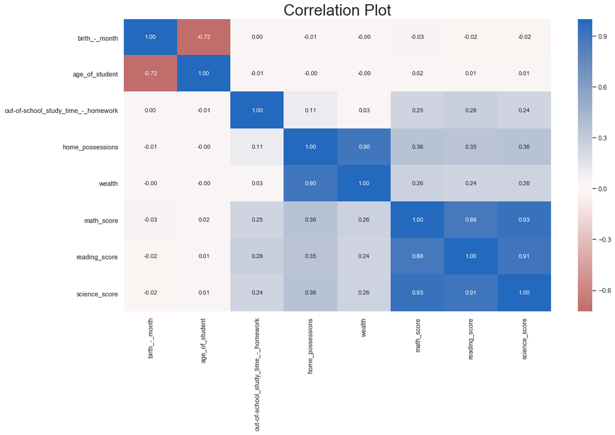

```python
# Correlation plot

fig = plt.figure(figsize=[16,9])
ax = sb.heatmap(df_pisa_small.sample(25000).corr(), annot = True, fmt = '.2f', cmap = 'vlag_r', center = 0)
ax.set_title("Correlation Plot", fontsize="26")
```

The correlation plot shows some strong correlations between the different pisa scores, indicating that a student with a good Pisa score in one discipline, use to achieve another high Pisa score in the other ones, which initially makes sense.

We can also appreciate that wealth, home possessions and the homework time are both also positively correlated with the different scores.

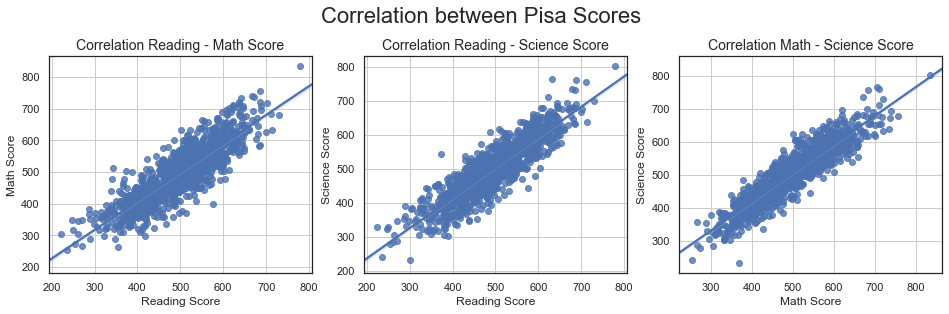

```python
# Let´s plot the scatterplots between the different Pisa scores to confirm what we have seen in the correlation matrix
plt.figure(figsize = [16,4])
plt.suptitle('Correlation between Pisa Scores', fontsize=22, y='1.05')

ax1 = plt.subplot(1, 3, 1) # 1 row, 3 cols, subplot 1
sb.regplot(data = df_sample, x = 'reading_score', y = 'math_score');
decorate_subplot(ax1, "Correlation Reading - Math Score", "Reading Score", "Math Score")

ax2 = plt.subplot(1, 3, 2)
sb.regplot(data = df_sample, x = 'reading_score', y = 'science_score');
decorate_subplot(ax2, "Correlation Reading - Science Score", "Reading Score", "Science Score")

ax3 = plt.subplot(1, 3, 3)
sb.regplot(data = df_sample, x = 'math_score', y = 'science_score');
decorate_subplot(ax3, "Correlation Math - Science Score", "Math Score", "Science Score")
```

Effectively, as we were expecting we see a strong correlation between scores. Those students that get good scores in one discipline, tend to get higher scores also on the others.

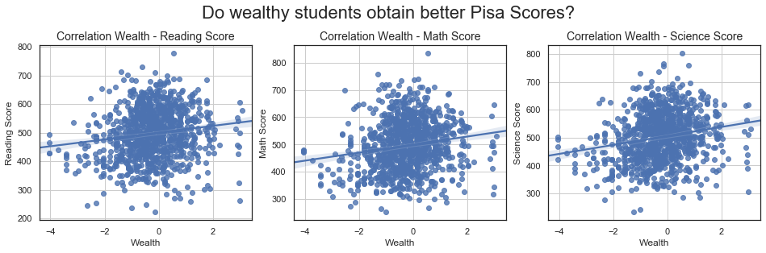

```python
# Let´s plot the correlation between wealth and the pisa scores
plt.figure(figsize = [16,4])
plt.suptitle('Do wealthy students obtain better Pisa Scores?', fontsize=22, y='1.05')

ax1 = plt.subplot(1, 3, 1) # 1 row, 3 cols, subplot 1
sb.regplot(data = df_sample, x = 'wealth', y = 'reading_score');
decorate_subplot(ax1, "Correlation Wealth - Reading Score", "Wealth", "Reading Score")

ax2 = plt.subplot(1, 3, 2)
sb.regplot(data = df_sample, x = 'wealth', y = 'math_score');
decorate_subplot(ax2, "Correlation Wealth - Math Score", "Wealth", "Math Score")

ax3 = plt.subplot(1, 3, 3)
sb.regplot(data = df_sample, x = 'wealth', y = 'science_score');
decorate_subplot(ax3, "Correlation Wealth - Science Score", "Wealth", "Science Score")
```

Also here we can confirm the positive correlation between wealth and the different PISA scores.

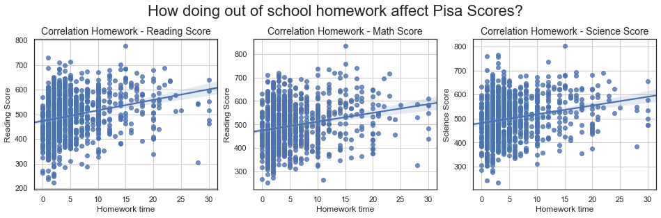

```python
# Let´s plot the correlation between the scores and the homework time
plt.figure(figsize = [16,4])
plt.suptitle('How doing out of school homework affect Pisa Scores?', fontsize=22, y='1.05')

ax1 = plt.subplot(1, 3, 1)
sb.regplot(data = df_sample, x = 'out-of-school_study_time_-_homework', y = 'reading_score');
decorate_subplot(ax1, "Correlation Homework - Reading Score", "Homework time", "Reading Score")

ax2 = plt.subplot(1, 3, 2)
sb.regplot(data = df_sample, x = 'out-of-school_study_time_-_homework', y = 'math_score');
decorate_subplot(ax2, "Correlation Homework - Math Score", "Homework time", "Reading Score")

ax3 = plt.subplot(1, 3, 3)
sb.regplot(data = df_sample, x = 'out-of-school_study_time_-_homework', y = 'science_score');
decorate_subplot(ax3, "Correlation Homework - Science Score", "Homework time", "Science Score")
```

Again, we can attest a positive correlation between the homework time and the scores achieved in Pisa.

Maybe wealthy students have more opportunities to dedicate some time to study. Let´s see the scatterplot between these two variables.

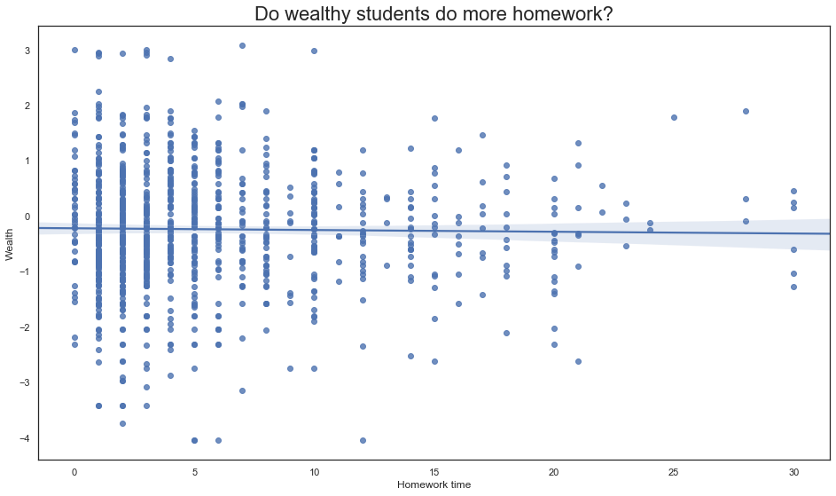

```python
# Let´s plot the correlation between wealth and study time out of school

# Plot the birth month variable
fig = plt.subplots(figsize=(16,9))
ax = sb.regplot(data = df_sample, x = 'out-of-school_study_time_-_homework', y = 'wealth');
decorate("Do wealthy students do more homework?", "Homework time", "Wealth")
```

No. Apparently, and as we could have checked in our correlation plot, there isn't any significant correlation between being a wealthy student and spend more time doing homework out of school.

Next, let´s see how the different scores relate with our categorical variables, starting with the number of books at home. Our hypothesis is that students with more books at home, should get higher scores. Let´s see if our data confirms it.

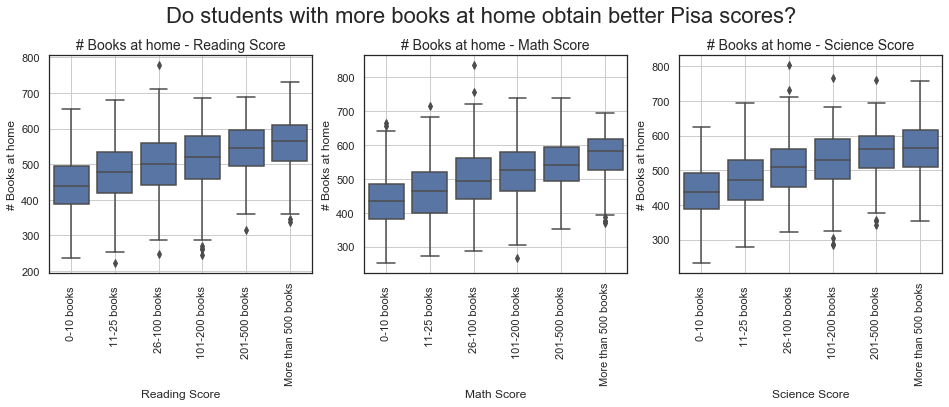

```python
# Boxplots relationing books at home - pisa scores
books_cat_order = ["0-10 books ", "11-25 books ", "26-100 books ", "101-200 books ", "201-500 books ", "More than 500 books"]
plt.figure(figsize = [16,4])
plt.suptitle('Do students with more books at home obtain better Pisa scores?', fontsize=22, y='1.05')

ax1 = plt.subplot(1, 3, 1)
sb.boxplot(data = df_sample, x = 'how_many_books_at_home', y = 'reading_score',
    color = base_color, order=books_cat_order)
decorate_subplot(ax1, "# Books at home - Reading Score", "Reading Score", "# Books at home")
plt.xticks(rotation=90)

ax2 = plt.subplot(1, 3, 2)
sb.boxplot(data = df_sample, x = 'how_many_books_at_home', y = 'math_score',
              color = base_color, order=books_cat_order)
decorate_subplot(ax2, "# Books at home - Math Score", "Math Score", "# Books at home")
plt.xticks(rotation=90)

ax3 = plt.subplot(1, 3, 3)
sb.boxplot(data = df_sample, x = 'how_many_books_at_home', y = 'science_score',
              color = base_color, order=books_cat_order)
decorate_subplot(ax3, "# Books at home - Science Score", "Science Score", "# Books at home")
plt.xticks(rotation=90)
```

Looking at the graphs, our hypothesis seems validated. The number of books at home seems like a good predictor of the different pisa scores.

Let´s analyze now, if owning a computer has any impact on your PISA scores.

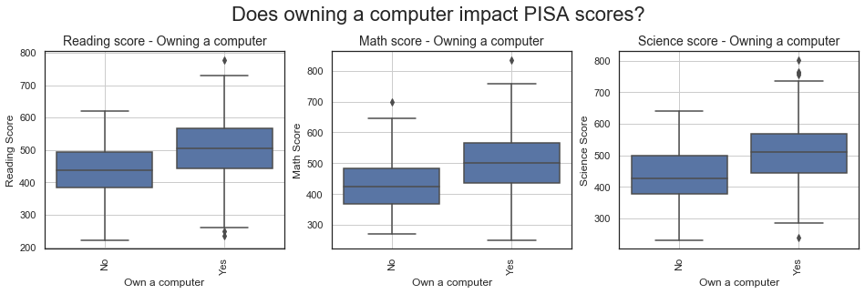

```python
# Boxplots relationing owning a computer and PISA scores
plt.figure(figsize = [16,4])
plt.suptitle('Does owning a computer impact PISA scores?', fontsize=22, y='1.05')

ax1 = plt.subplot(1, 3, 1)
sb.boxplot(data = df_sample, x = 'possessions_-_computer', y = 'reading_score', color = base_color)
decorate_subplot(ax1, "Reading score - Owning a computer", "Own a computer", "Reading Score")
plt.xticks(rotation=90);

ax2 = plt.subplot(1, 3, 2)
sb.boxplot(data = df_sample, x = 'possessions_-_computer', y = 'math_score', color = base_color)
decorate_subplot(ax2, "Math score - Owning a computer", "Own a computer", "Math Score")
plt.xticks(rotation=90);

ax3 = plt.subplot(1, 3, 3)
sb.boxplot(data = df_sample, x = 'possessions_-_computer', y = 'science_score', color = base_color)
decorate_subplot(ax3, "Science score - Owning a computer", "Own a computer", "Science Score")
plt.xticks(rotation=90);
```

Apparently owning a computer seems to have a significant impact on the different PISA scores. We are starting to see that having access to certain possessions as books and computer, both related with being wealthy, increases your chances of getting better grades.

### Talk about some of the relationships you observed in this part of the investigation. How did the feature(s) of interest vary with other features in the dataset?

We have observed some interesting aspects in this part of the project:

- First, we have discovered how the different pisa scores are highly correlated between them, indicating that students that do well in one of them, use to do well in the others as well.
- Then, we have found how wealth also has a positive influence on the scores.
- We have shown also how the time invested doing homework pays also with better grades.
- The number of books at home seem a good predictor of your pisa scores. As the number increases, so do your pisa score.
- The same happens with owning a computer. Students owning a computer in the study, tend to show significantly better grades.

### Did you observe any interesting relationships between the other features (not the main feature(s) of interest)?

The most interesting has been discover that although doing homework at home is correlated positively with obtaining better qualifications, this is not the reason that wealthy students get better ones, as we haven´t found any positive correlation between wealth and the time spent doing homework.

## Multivariate Exploration

We´ve seen that having books at home and owning a computer increases your PISA scores. What we haven´t seen until now is that students having access to both resources are the ones who get the better scores.

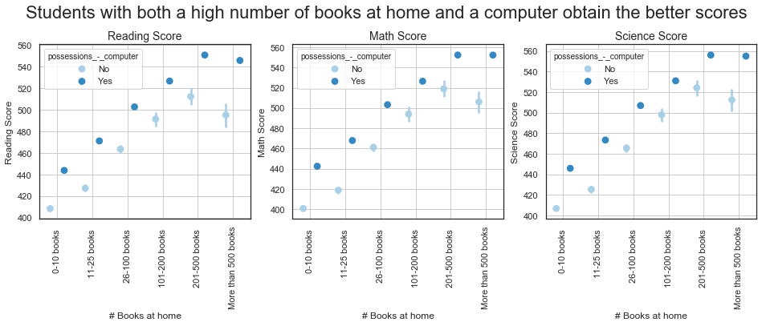

```python
# Relationship between 2 categorical and 1 numerical variable
fig = plt.figure(figsize = [16,4])
plt.suptitle('Students with both a high number of books at home and a computer obtain the better scores', fontsize=22, y='1.05')

plt.subplot(1, 3, 1)
ax1 = sb.pointplot(data = df_clean, x = 'how_many_books_at_home', y = 'reading_score', hue = 'possessions_-_computer',
           palette = 'Blues', linestyles = '', dodge = 0.4, order=books_cat_order);
decorate_subplot(ax1, "Reading Score", "# Books at home", "Reading Score");
plt.xticks(rotation=90);

plt.subplot(1, 3, 2)
ax2 = sb.pointplot(data = df_clean, x = 'how_many_books_at_home', y = 'math_score', hue = 'possessions_-_computer',
           palette = 'Blues', linestyles = '', dodge = 0.4, order=books_cat_order);
decorate_subplot(ax2, "Math Score", "# Books at home", "Math Score");
plt.xticks(rotation=90);

plt.subplot(1, 3, 3)
ax3 = sb.pointplot(data = df_clean, x = 'how_many_books_at_home', y = 'science_score', hue = 'possessions_-_computer',
           palette = 'Blues', linestyles = '', dodge = 0.4, order=books_cat_order);
decorate_subplot(ax3, "Science Score", "# Books at home", "Science Score");
plt.xticks(rotation=90);
```

Not surprisingly, students that have both a high number of books at home and a computer, obtain the better PISA scores. This seem to indicate that wealth is an important factor to get high scores.

Let´s check this plotting the relationship between Wealth, Home Possessions and PISA scores of our sample.

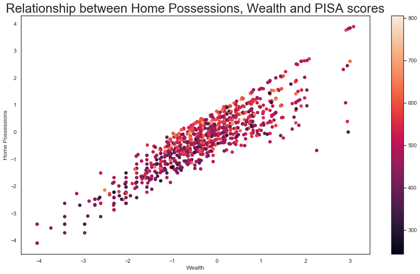

```python
# Relationship between 3 numeric variables
fig = plt.subplots(figsize=(16,9))
plt.scatter(data = df_sample, x = 'wealth', y = 'home_possessions', c = 'pisa_score_average');
plt.colorbar();
plt.title("Relationship between Home Possessions, Wealth and PISA scores", fontsize='26');
plt.xlabel("Wealth");
plt.ylabel("Home Possessions");
```

Effectively, we can see how the brighter points in the graph are mostly in the top area of the resulting graph, corresponding to those students with high levels of wealth and home possessions.

## Conclussions

- Wealth level of students has a clear positive effect on their PISA scores
- Wealthy students do not study out of class more than non wealthy ones
- Students with more books at home tend to obtain better scores.
- Also, owning a computer seems to be positively correlated with getting better scores.
- Wealthy students have greater chances of having more books at home and owning a computer.
- Students with a high number of books at home and who own a computer are ones getting the higher scores.

Given our analysis, we can conclude that apparently, wealth levels are an important factor in the academic performance of students.